# Sensitivity testing: Yield bright spots

## 2.5. Informative Gamma priors on the precisions for the STATE effect

The `prec` (precision) priors are generally logGamma with parameters $\alpha$ and $b$ which define the shape of the gamma distribution. The default settings for these models are not very imformative. We can add more informative gamma priors for the precisions in the model. We could, for example, define the mean value of the gamma prior to the inverse of the variance of the residuals of the fixed-effects only model (read more [here](http://www.maths.bath.ac.uk/~jjf23/inla/multilevel.html#informative-gamma-priors-on-the-precisions) and [here](http://www.maths.bath.ac.uk/~jjf23/inla/nested.html)). We expect the variances to be lowest than this variance, so this is an overestimate. The variance of the gamma prior (for the precison) is controlled by the $\alpha$ shape parameter, where smaller values are less informative. Note that I re-ran the models with a lowest value of $\alpha$ (so less informative priors), this really increased the precision on the spatial parameters (so adding some information helps this) and significantly reduced model fit. We’ll stick with the informative gamma priors on the `STATE` effect based on the variance of the residuals from a simple linear model. I also tried to decrease the value of $b$ (as if I used residuals from a linear model with fixed effects). This model still had a high precision for the county-level precision, but that’s because we haven’t added PC priors yet. Model fit wasn’t better than with the higher value of $b$.

The final model improves model fit as compared to 2.4:

```r
# state log-gamma priors
a <- 0.5
lmod <- lm(YIELD ~ factor(YEAR) + GDD + SDD + TP, data = null)
b <- a*var(residuals(lmod))

# rw1 prior information
u <- sd(null$YIELD)

formula <- YIELD ~ 1 + f(ID, model = "bym",
                         graph = hadj,
                         scale.model = TRUE,
                         constr = TRUE) +
  PERC_IRR +
  f(STATE, model = "iid", hyper = list(prec = list(prior = "loggamma", param = c(a, b)))) +
  f(GDD, model = "rw1", scale.model = T, hyper = list(theta = list(prior = "pc.prec",
                                                                   param = c(u, 0.01)))) +
  f(SDD, model = "rw1", scale.model = T, hyper = list(theta = list(prior = "pc.prec",
                                                                   param = c(u, 0.01)))) +
  f(TP, model = "rw1", scale.model = T, hyper = list(theta = list(prior = "pc.prec",
                                                                   param = c(u, 0.01)))) +
  factor(YEAR)

o5 <- inla(formula, data=null, family="gaussian",
           control.predictor = list(compute=T),
           control.compute = list(dic=T, cpo=T))
d <- model_diagnostics(o5, null)
summary(o5) # high precision for ID iid
```

```
##
## Call:
## c("inla(formula = formula, family = \"gaussian\", data = null, control.compute = list(dic = T, ",  "    cpo = T), control.predictor = list(compute = T))")
##
## Time used:
##  Pre-processing    Running inla Post-processing           Total
##          2.1938        138.6995          0.7520        141.6452
##
## Fixed effects:
##                     mean     sd 0.025quant 0.5quant 0.975quant    mode kld
## (Intercept)      72.4833 4.6649    63.3157  72.4851    81.6344 72.4894   0
## PERC_IRR         62.7595 2.4856    57.8796  62.7594    67.6355 62.7595   0
## factor(YEAR)2002  3.4395 1.0250     1.4274   3.4393     5.4508  3.4391   0
## factor(YEAR)2007 18.6808 1.0774    16.5653  18.6808    20.7941 18.6810   0
## factor(YEAR)2012 14.8586 1.0730    12.7522  14.8585    16.9638 14.8584   0
##
## Random effects:
## Name   Model
##  ID   BYM model
## STATE   IID model
## GDD   RW1 model
## SDD   RW1 model
## TP   RW1 model
##
## Model hyperparameters:
##                                              mean        sd 0.025quant
## Precision for the Gaussian observations    0.0013    0.0000     0.0013
## Precision for ID (iid component)        1490.6324 2564.3206    64.1598
## Precision for ID (spatial component)    1765.1844 2016.0784    28.9293
## Precision for STATE                        0.0016    0.0004     0.0010
## Precision for GDD                          0.0048    0.0010     0.0030
## Precision for SDD                          0.0079    0.0015     0.0051
## Precision for TP                           0.0164    0.0062     0.0082
##                                          0.5quant 0.975quant     mode
## Precision for the Gaussian observations    0.0013     0.0014   0.0013
## Precision for ID (iid component)         742.3920  7598.2459 160.5120
## Precision for ID (spatial component)    1043.9117  7112.5765  29.3627
## Precision for STATE                        0.0015     0.0025   0.0014
## Precision for GDD                          0.0048     0.0070   0.0047
## Precision for SDD                          0.0079     0.0109   0.0079
## Precision for TP                           0.0151     0.0319   0.0129
##
## Expected number of effective parameters(std dev): 144.23(2.052)
## Number of equivalent replicates : 52.87
##
## Deviance Information Criterion (DIC) ...............: 71694.14
## Deviance Information Criterion (DIC, saturated) ....: 7159.56
## Effective number of parameters .....................: 122.11
##
## Marginal log-Likelihood:  -36345.70
## CPO and PIT are computed
##
## Posterior marginals for linear predictor and fitted values computed
```

```r
d$DIC #67994
```

```
## [1] 71694.14
```

```r
d$R2 #0.69
```

```
## [1] 0.4876836
```

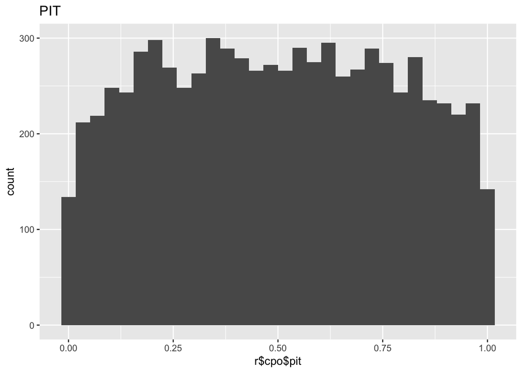

```r
d$PIT # uniform
```